# Visualisierungen

28 März 2019

## ggplot2

[ggplot2](https://ggplot2.tidyverse.org/) ist das Grafikpaket im *tidyverse*

Es basiert auf [The Grammar of Graphics](https://www.amazon.de/Grammar-Graphics-Statistics-Computing/dp/0387245448/ref=sr_1_1?ie=UTF8&qid=1551865404&sr=8-1&keywords=The+Grammar+of+Graphics)

Einheitliches System zum Beschreiben und Erstellen von Grafiken

Vorteile:

- schneller (einfacher Transfer von gelernten Techniken)
- schöner (*Pit of Success*)

```r
library(tidyverse)
```

## ggplot Grafiken bestehen aus mehreren Layern

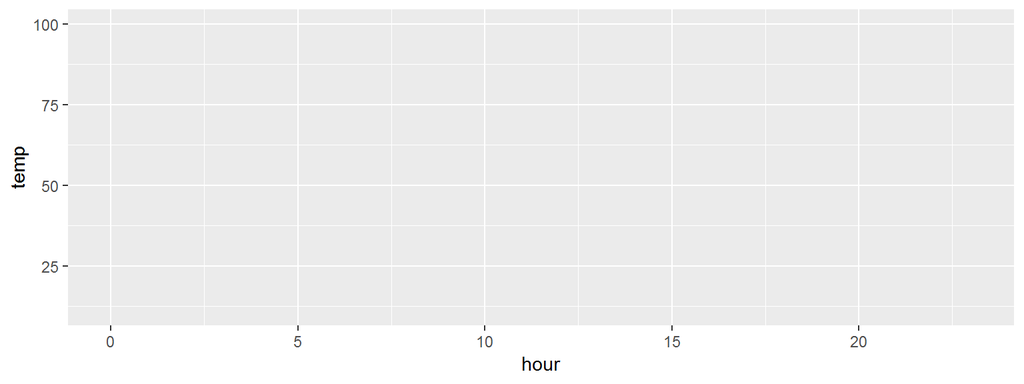

```r
nycflights13::weather %>%
  ggplot(aes(x=hour, y=temp))
```

## ggplot Grafiken bestehen aus mehreren Layern

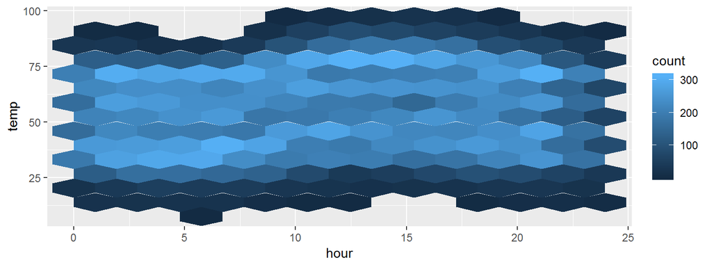

```r
nycflights13::weather %>%
  ggplot(aes(x=hour, y=temp)) +
    geom_hex(bins = 12)
```

## ggplot Grafiken bestehen aus mehreren Layern

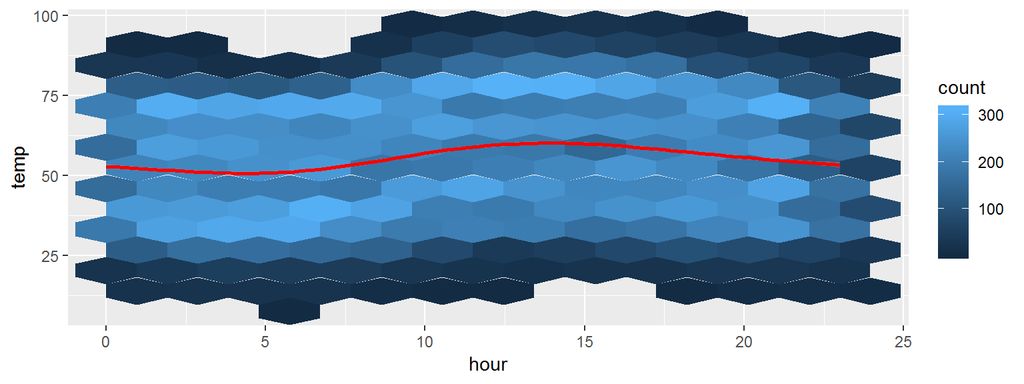

```r
nycflights13::weather %>%
  ggplot(aes(x=hour, y=temp)) +
    geom_hex(bins = 12)+
    geom_smooth(color="red")
```

## Grammatik - Elemente

**geom**: die geometrische Form/Figur um Daten darzustellen

- bar, point, line, violine, ribbon, text, hex, …

**aesthetic**: Attribute um *geom* zu kontrollieren (mapping)

- x,y-Position, Farbe, Füllung, Größe, Form, …

**stat**: Transformationen der Daten bevor sie in *geom* gepackt werden

- binning, count, …

**scale**: Umwandlung von Daten in Grafikattribute

- Link zwischen *aesthetic* und Daten

**guide**: Helfen *aesthetic* in Daten umzuwandeln

- Legenden, Achsen

## Basis Syntax

ggplot( Daten,

aes( mappings) +

geom_…( aes(weitere mappings)),

nicht variable abhängige Anpassungen) +

scale_…( Anpassungen der Skala) +

facet_…( Aufsplitten der Grafik in Facetten ) +

theme…( Allgemeine Anpassungen)

## Regeln für Daten

Benutze `tibble`

Benutze `factor`

Beherrsche `factor`

Halte deine Daten **tidy**

Bringe Daten in **richtige Form**

Wenn eine ggplot Grafik nicht funktioniert,

dann frage dich: *Halte ich mich an die Regeln?*

## Faktoren Beispiel

Erstelle Daten

```r
month_temp <- tibble::tribble(
       ~month, ~mean_temp,
    "January",        1.9,
   "February",        1.2,
      "March",        4.2,
      "April",       10.1,
        "May",       15.2,
       "June",       21.1,
       "July",         26,
     "August",       23.2,
  "September",       19.4,
    "October",       15.4,
   "November",        7.3,
   "December",        3.7
  )
```

## Faktoren Beispiel

Blick auf Daten

```r
month_temp
```

```
## # A tibble: 12 x 2
##    month     mean_temp
##    <chr>         <dbl>
##  1 January         1.9
##  2 February        1.2
##  3 March           4.2
##  4 April          10.1
##  5 May            15.2
##  6 June           21.1
##  7 July           26
##  8 August         23.2
##  9 September      19.4
## 10 October        15.4
## 11 November        7.3
## 12 December        3.7
```

## Faktoren Beispiel

Probiere zu ploten

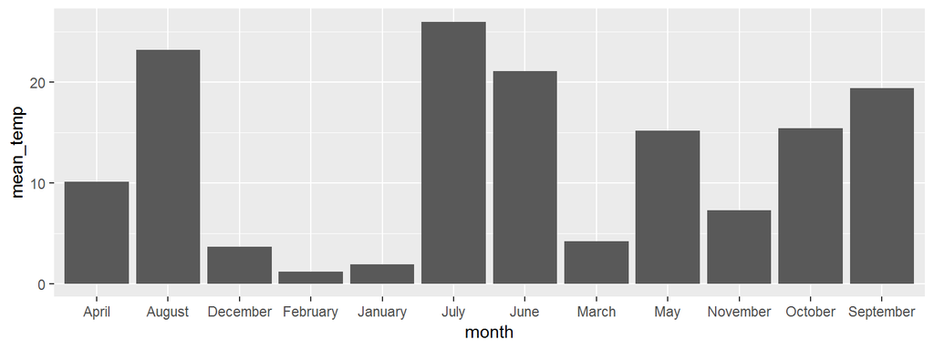

```r
month_temp %>%
  ggplot(aes(x=month, y=mean_temp)) +
    geom_bar(stat="identity")
```

## Faktoren Beispiel

Konvertiere in Faktor

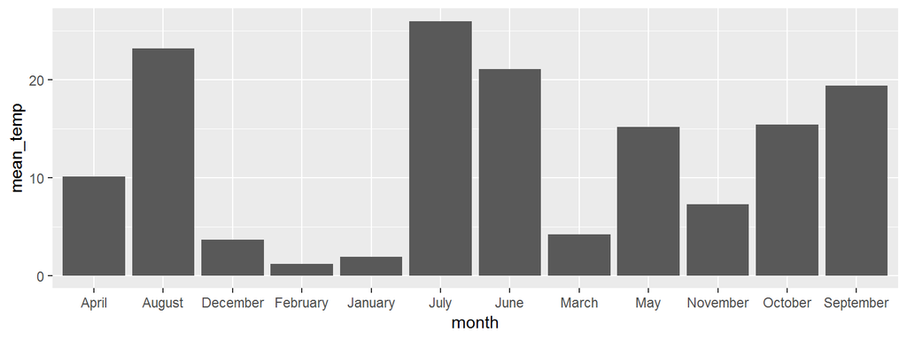

```r
month_temp %>%
  mutate(month = factor(month)) %>%
  ggplot(aes(x=month, y=mean_temp)) +
    geom_bar(stat="identity")
```

Notiz: `forcats::as_factor()` statt `factor()` würde funkionieren, da nach Reihenfolge

## Faktoren Beispiel

Das Paket `forcats` (in tidyverse enthalten) bietet viele Tools um Reihenfolge eines Faktors zu ändern.

Das allgemeinste ist `fct_relevel()`

```r
month_temp_relev <- month_temp %>%
  mutate(
    month = fct_relevel( month,
        "January", "February",  "March", "April",
        "May", "June", "July", "August",
        "September", "October", "November", "December")
  )
```

## Faktoren Beispiel

Probiere zu ploten

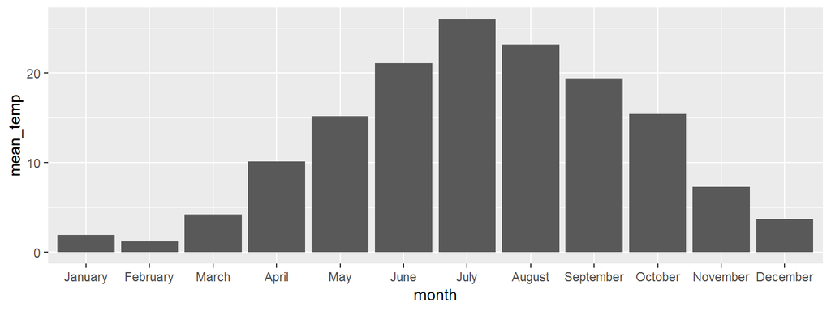

```r
month_temp_relev %>%
  ggplot(aes(x=month, y=mean_temp)) +
    geom_bar(stat="identity")
```

## Faktoren Beispiel

Sortierung nach *mean_temp* mit `forcats::fct_reorder()`

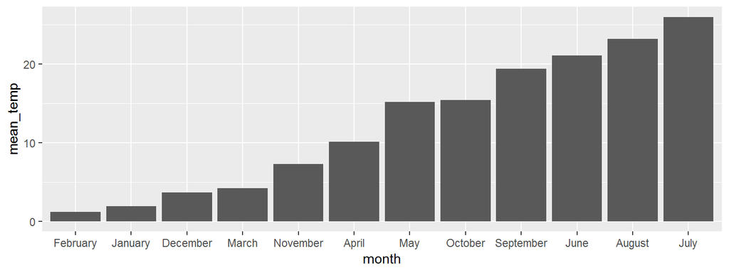

```r
month_temp_relev %>%
  mutate(
    month = fct_reorder(month, mean_temp, .fun=mean)
  ) %>%
  ggplot(aes(x=month, y=mean_temp)) +
    geom_bar(stat="identity")
```

## geom

## Kleine Auswahl an `geom`s

| geom | benötigt | optional |
| --- | --- | --- |
| geom_bar() | x: Variable für x-Achse | y, color, size, fill, linetype, alpha (Transparenz) |
| geom_point() | x, y | shape, colour, size, fill, alpha |
| geom_line() | x, y | colour, size, linetype, alpha |
| geom_smooth() | x, y | colour, size, fill, linetype, alpha |
| geom_histogram() | x, y | colour, size, fill, linetype, alpha |
| geom_boxplot() | x | colour, size, fill, alpha |
| geom_errorbar() | x, ymin, ymax | colour, size, linetype, width, alpha |

Für mehr siehe [offizielle Referenz](https://ggplot2.tidyverse.org/reference/)

## geom_bar()

benötigt, kein y, sondern berechnet Anzahl per default

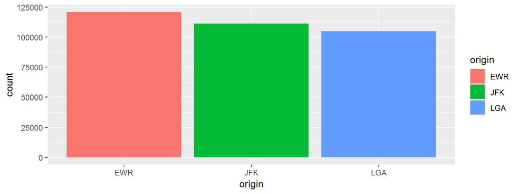

```r
flights %>%
  ggplot(aes(x=origin, fill=origin)) +
    geom_bar()
```

## geom_point()

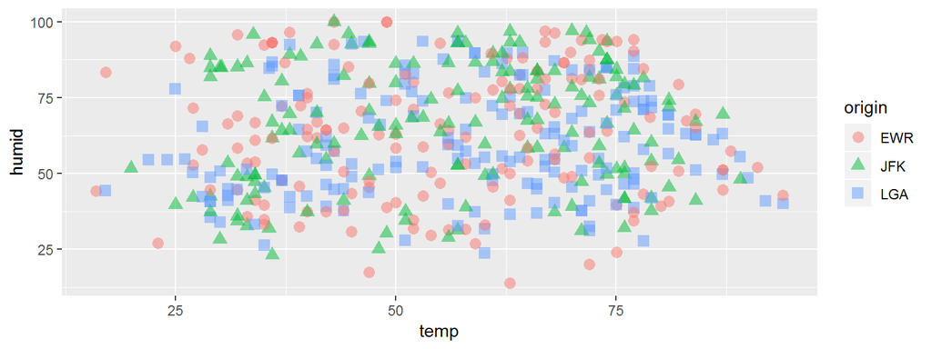

```r
weather %>%
  sample_n(500) %>%
  ggplot(aes(x=temp, y=humid, shape=origin, color=origin)) +
    geom_point(size=3, alpha=0.5)
```

## geom_line()

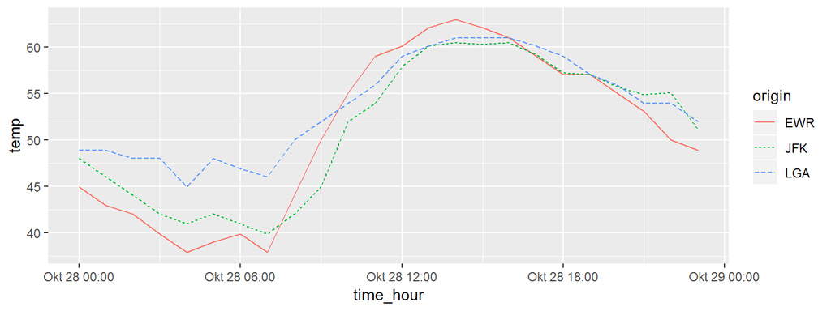

```r
weather %>%
  filter(month==10, day==28) %>%
  ggplot(aes(x=time_hour, y=temp, linetype=origin, color=origin)) +
    geom_line()
```

## geom_smooth()

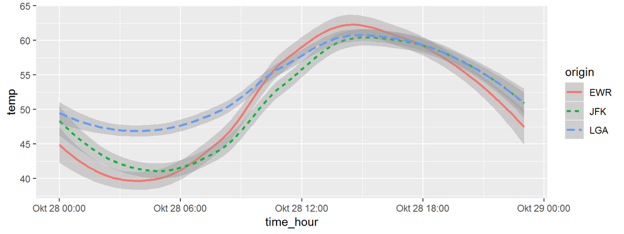

```r
weather %>%
  filter(month==10, day==28) %>%
  ggplot(aes(x=time_hour, y=temp, linetype=origin, color=origin)) +
    geom_smooth()
```

## geom_histogram()

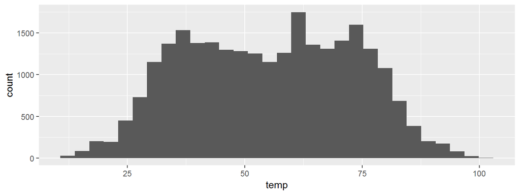

```r
weather %>%
  ggplot(aes(x=temp)) +
    geom_histogram()
```

## geom_boxplot()

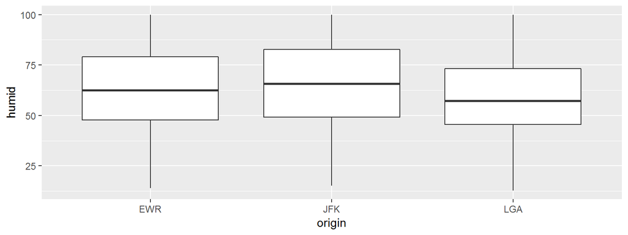

```r
weather %>%
  ggplot(aes(x=origin, y=humid)) +
    geom_boxplot()
```

## geom_errorbar()

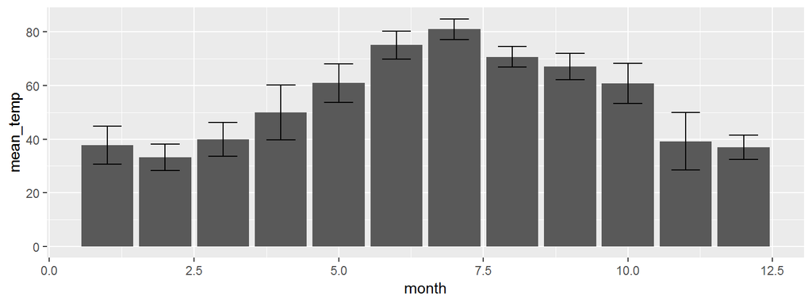

```r
weather %>%
  sample_n(100) %>%
  group_by(month) %>%
  summarize(
    mean_temp = mean(temp, na.rm = T),
    se_temp = plotrix::std.error(temp)
  ) %>%
  ggplot(aes(x=month, y = mean_temp)) +
    geom_bar(stat = "identity") +
    geom_errorbar(aes(ymin = mean_temp-2*se_temp, ymax=mean_temp+2*se_temp), width=0.5)
```

## Übung

Erstelle folgende Grafik mit `weather %>% filter(origin=="JFK")` und den geoms `geom_violin()` & `geom_boxplot()`.

Tipp: `month.name` ist ein Vektor der Monatsnamen

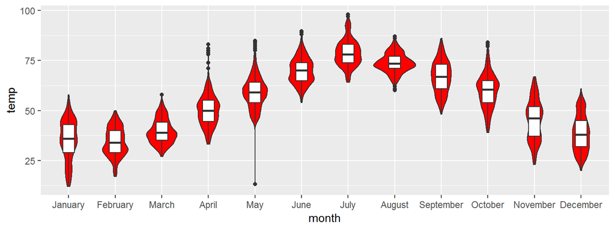

## Lösung

```r
weather %>%
  filter(origin=="JFK") %>%
  mutate(month = month.name[month],
         month = as_factor(month)) %>%
  ggplot(aes(x=month, y=temp)) +
    geom_violin(fill="red") +
    geom_boxplot(width=0.25)
```

## Skalen

## Skalentypen

Jedes Mapping in den **aesthetics** hat eine eigene Skala

Beispiele:

| Skala | betrifft |
| --- | --- |
| `scale_x_discrete()` | Diskrete (factor) x-Werte |
| `scale_y_contiuous()` | Kontinuierliche y-Werte |
| `scale_fill_...()` | Farbe der Füllung |
| `scale_linetype()` | Linientyp |

## Skalenname = Achsenname

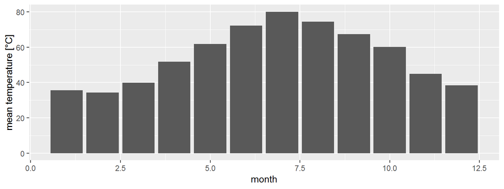

```r
weather %>%
  group_by(month) %>%
  summarize(mean_temp = mean(temp, na.rm = T))  %>%
  ggplot(aes(x=month, y=mean_temp)) +
    geom_bar(stat="identity") +
    scale_y_continuous(name = "mean temperature [°C]")
```

## Wähle Skalenbereich mit `limits`

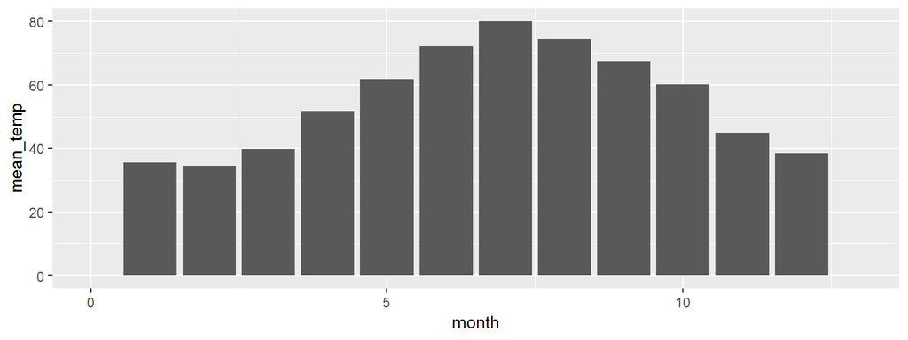

```r
weather %>%
  group_by(month) %>%
  summarize(mean_temp = mean(temp, na.rm = T))  %>%
  ggplot(aes(x=month, y=mean_temp)) +
    geom_bar(stat="identity") +
    scale_x_continuous(limits = c(0, 13))
```

## Wähle Graduierungsschritte mit `breaks`

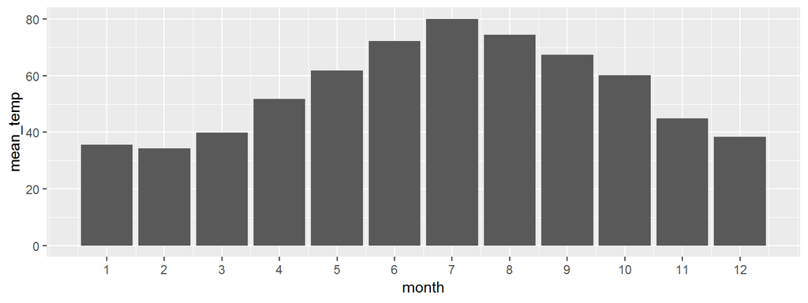

```r
weather %>%
  group_by(month) %>%
  summarize(mean_temp = mean(temp, na.rm = T))  %>%
  ggplot(aes(x=month, y=mean_temp)) +
    geom_bar(stat="identity") +
    scale_x_continuous(breaks = 1:12)
```

## Benenne Graduierungsschritte mit `labels`

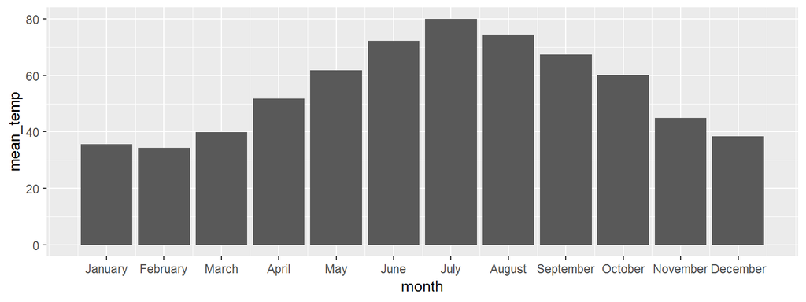

```r
weather %>%
  group_by(month) %>%
  summarize(mean_temp = mean(temp, na.rm = T))  %>%
  ggplot(aes(x=month, y=mean_temp)) +
    geom_bar(stat="identity") +
    scale_x_continuous(breaks = 1:12, labels = month.name)
```

## Wähle andere Werte mit `values` (Farben, Formen, …)

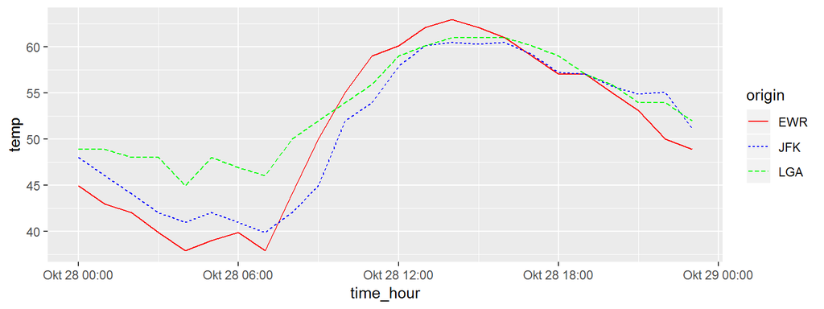

```r
weather %>%
  filter(month==10, day==28) %>%
  ggplot(aes(x=time_hour, y=temp, linetype=origin, color=origin)) +
    geom_line() +
    scale_color_manual(values = c("red", "blue", "green"))
```

für Farbenüberblick siehe [hier](http://sape.inf.usi.ch/quick-reference/ggplot2/colour).

## Nicht gut in Farbauswahl? Nutze Paletten!

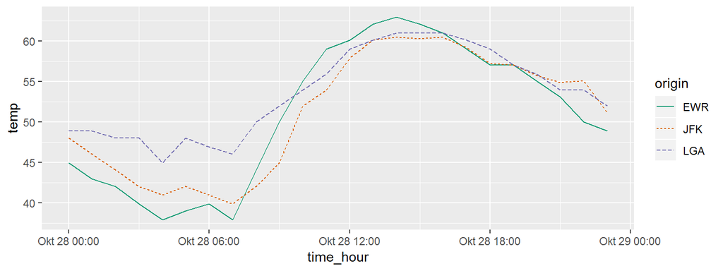

```r
weather %>%
  filter(month==10, day==28) %>%
  ggplot(aes(x=time_hour, y=temp, linetype=origin, color=origin)) +
    geom_line() +
    scale_color_brewer(palette = "Dark2")
```

Mehr dazu [hier](https://ggplot2.tidyverse.org/reference/scale_brewer.html)

## Auch Skalentransformation ist möglich

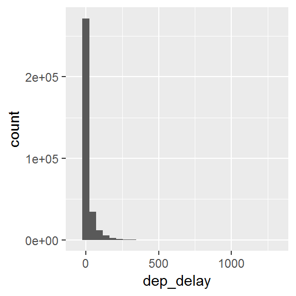

```r
flights  %>%
  ggplot(aes(x=dep_delay)) +
  geom_histogram()
```

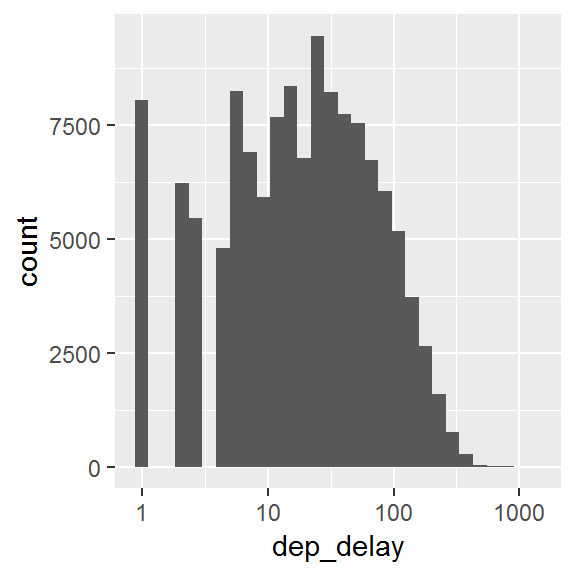

```r
flights  %>%
  ggplot(aes(x=dep_delay)) +
  geom_histogram() +
  scale_x_log10()
```

## und Achsentausch

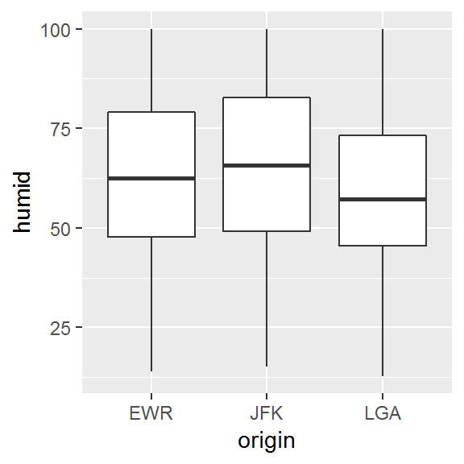

```r
weather %>%
  ggplot(aes(x=origin, y=humid)) +
    geom_boxplot()
```

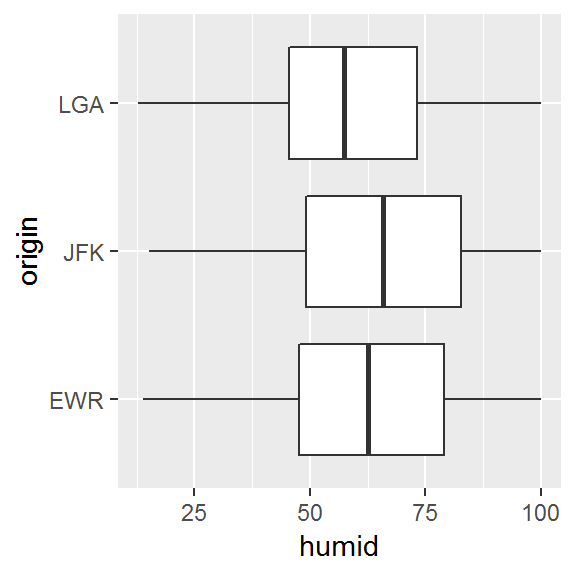

```r
weather %>%
  ggplot(aes(x=origin, y=humid)) +
    geom_boxplot() +
    coord_flip()
```

## Übung

Erstelle folgende Grafik mit `weather`:

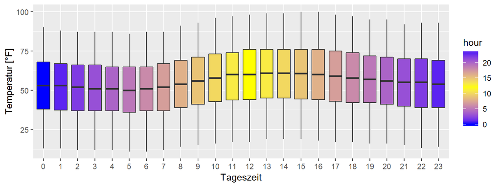

Tipp: `scale_fill_gradient2()`

## Lösung:

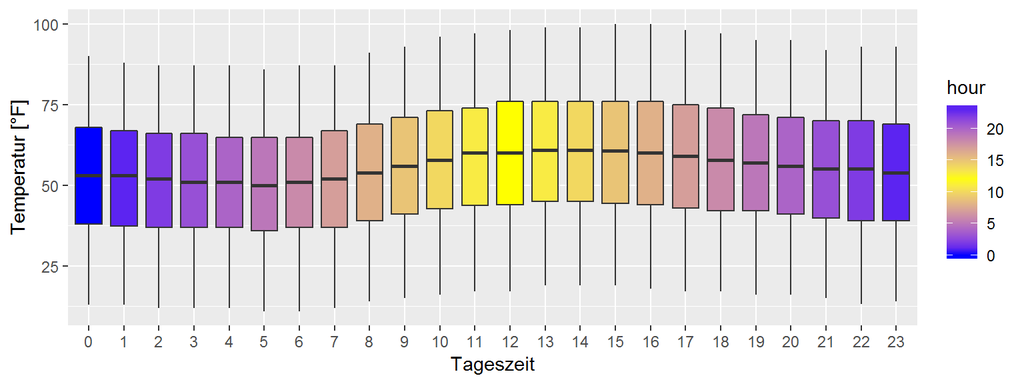

```r
weather %>%
  mutate(Hour=as_factor(hour)) %>%
  ggplot(aes(x=Hour, y=temp, fill=hour)) +
    geom_boxplot() +
    scale_fill_gradient2(low="blue", mid="yellow", high="blue", midpoint=12) +
    scale_y_continuous(name="Temperatur [°F]") +
    scale_x_discrete(name="Tageszeit")
```

## Facetten

## Facetten

Facetten teilen die Daten basierend auf Faktoren und erzeugen für jede Faktorausprägung die selbe Grafik.

Wir bereiten Daten vor:

```r
weather_fac <- weather %>%
  mutate(
    time = if_else(hour < 5 | hour > 18, "night", "day"),
    month = factor(month, labels=month.name)
  )
```

## Base Plot

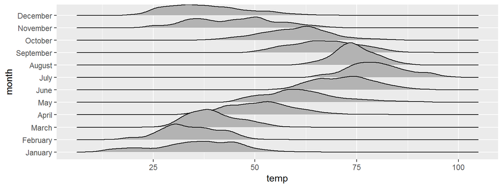

```r
weather_fac %>%
  ggplot(aes(x=temp, y=month)) +
    ggridges::geom_density_ridges()
```

## Horizontale Facetten

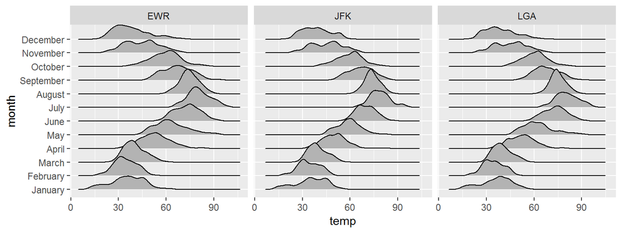

```r
weather_fac %>%
  ggplot(aes(x=temp, y=month)) +
    ggridges::geom_density_ridges() +
    facet_grid(.~origin)
```

## Vertikale Facetten

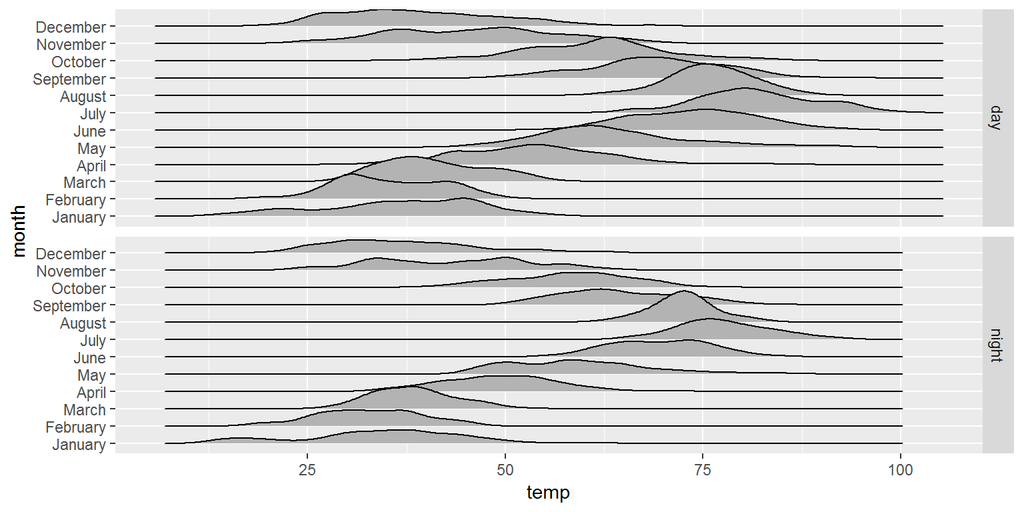

```r
weather_fac %>%
  ggplot(aes(x=temp, y=month)) +
    ggridges::geom_density_ridges() +
    facet_grid(time~.)
```